# Confidence intervals

A confidence interval (CI) tells us within what range we may be certain to find the true mean from which any sample has been taken. If we were to repeatedly sample the same population over and over and calculated a mean every time, the 95% CI indicates the range that 95% of those means would fall into.

## Calculating confidence

```r
Input <- ("
Student  Grade   Teacher   Score  Rating
a        Gr_1    Vladimir  80     7
b        Gr_1    Vladimir  90    10
c        Gr_1    Vladimir 100     9
d        Gr_1    Vladimir  70     5
e        Gr_1    Vladimir  60     4
f        Gr_1    Vladimir  80     8
g        Gr_10   Vladimir  70     6
h        Gr_10   Vladimir  50     5
i        Gr_10   Vladimir  90    10
j        Gr_10   Vladimir  70     8
k        Gr_1    Sadam     80     7
l        Gr_1    Sadam     90     8
m        Gr_1    Sadam     90     8
n        Gr_1    Sadam     80     9
o        Gr_10   Sadam     60     5
p        Gr_10   Sadam     80     9
q        Gr_10   Sadam     70     6
r        Gr_1    Donald   100    10
s        Gr_1    Donald    90    10
t        Gr_1    Donald    80     8
u        Gr_1    Donald    80     7
v        Gr_1    Donald    60     7
w        Gr_10   Donald    60     8
x        Gr_10   Donald    80    10
y        Gr_10   Donald    70     7
z        Gr_10   Donald    70     7
")

data <- read.table(textConnection(Input), header = TRUE)
summary(data)
```

```
R>    Student             Grade             Teacher              Score
R>  Length:26          Length:26          Length:26          Min.   : 50.00
R>  Class :character   Class :character   Class :character   1st Qu.: 70.00
R>  Mode  :character   Mode  :character   Mode  :character   Median : 80.00
R>                                                           Mean   : 76.92
R>                                                           3rd Qu.: 87.50
R>                                                           Max.   :100.00
R>      Rating
R>  Min.   : 4.000
R>  1st Qu.: 7.000
R>  Median : 8.000
R>  Mean   : 7.615
R>  3rd Qu.: 9.000
R>  Max.   :10.000
```

The package **rcompanion** has a convenient function for estimating the confidence intervals for our sample data. The function is called `groupwiseMean()` and it has a few options (methods) for estimating the confidence intervals, e.g. the ‘traditional’ way using the *t*-distribution, and a bootstrapping procedure.

Let us produce the confidence intervals using the traditional method for the group means:

```r
library(rcompanion)
# Ungrouped data are indicated with a 1 on the right side of the formula,
# or the group = NULL argument; so, this produces the overall mean
groupwiseMean(Score ~ 1, data = data, conf = 0.95, digits = 3)
```

```
R>    .id  n Mean Conf.level Trad.lower Trad.upper
R> 1 <NA> 26 76.9       0.95       71.7       82.1
```

```r
# One-way data
groupwiseMean(Score ~ Grade, data = data, conf = 0.95, digits = 3)
```

```
R>   Grade  n Mean Conf.level Trad.lower Trad.upper
R> 1  Gr_1 15   82       0.95       75.3       88.7
R> 2 Gr_10 11   70       0.95       62.6       77.4
```

```r
# Two-way data
groupwiseMean(Score ~ Teacher + Grade, data = data, conf = 0.95, digits = 3)
```

```
R>    Teacher Grade n Mean Conf.level Trad.lower Trad.upper
R> 1   Donald  Gr_1 5   82       0.95       63.6      100.0
R> 2   Donald Gr_10 4   70       0.95       57.0       83.0
R> 3    Sadam  Gr_1 4   85       0.95       75.8       94.2
R> 4    Sadam Gr_10 3   70       0.95       45.2       94.8
R> 5 Vladimir  Gr_1 6   80       0.95       65.2       94.8
R> 6 Vladimir Gr_10 4   70       0.95       44.0       96.0
```

Now let us do it through bootstrapping:

```r
groupwiseMean(Score ~ Grade,
              data = data,
              conf = 0.95,
              digits = 3,
              R = 10000,
              boot = TRUE,
              traditional = FALSE,
              normal = FALSE,
              basic = FALSE,
              percentile = FALSE,
              bca = TRUE)
```

```
R>   Grade  n Mean Boot.mean Conf.level Bca.lower Bca.upper
R> 1  Gr_1 15   82      81.9       0.95      74.7      86.7
R> 2 Gr_10 11   70      70.0       0.95      62.7      75.5
```

```r
groupwiseMean(Score ~ Teacher + Grade,
              data = data,
              conf = 0.95,
              digits = 3,
              R = 10000,
              boot = TRUE,
              traditional = FALSE,
              normal = FALSE,
              basic = FALSE,
              percentile = FALSE,
              bca = TRUE)
```

```
R>    Teacher Grade n Mean Boot.mean Conf.level Bca.lower Bca.upper
R> 1   Donald  Gr_1 5   82        82       0.95      68.0      90.0
R> 2   Donald Gr_10 4   70        70       0.95      60.0      75.0
R> 3    Sadam  Gr_1 4   85        85       0.95      80.0      87.5
R> 4    Sadam Gr_10 3   70        70       0.95      60.0      76.7
R> 5 Vladimir  Gr_1 6   80        80       0.95      68.3      88.3
R> 6 Vladimir Gr_10 4   70        70       0.95      55.0      80.0
```

These upper and lower limits may then be used easily within a figure.

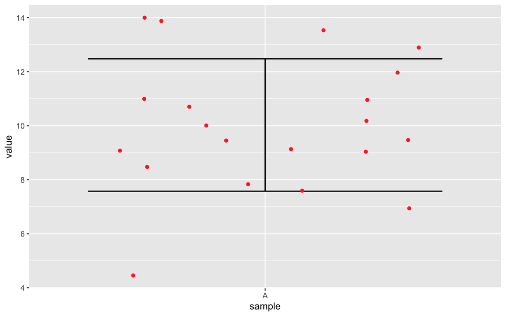

```r
# Load libraries
library(tidyverse)

# Create dummy data
r_dat <- data.frame(value = rnorm(n = 20, mean = 10, sd = 2),
                    sample = rep("A", 20))

# Create basic plot
ggplot(data = r_dat, aes(x = sample, y = value)) +
  geom_errorbar(aes(ymin = mean(value) - sd(value), ymax = mean(value) + sd(value))) +
  geom_jitter(colour = "firebrick1")
```

## CI of compared means

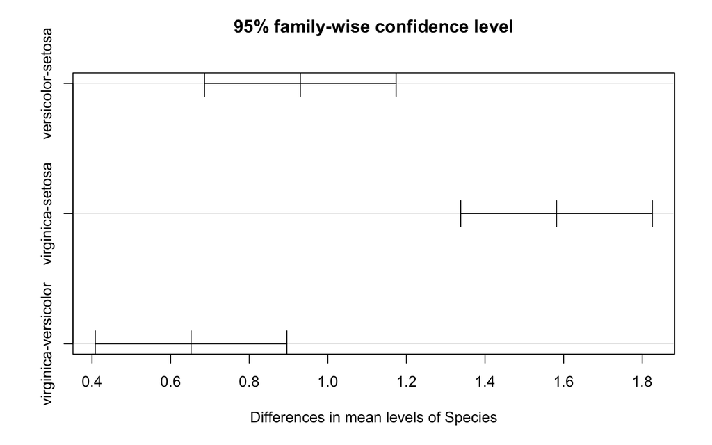

Results of a post-hoc Tukey test showing the confidence interval for the effect size between each group.

```r
# First calculate ANOVA of seapl length of different iris species
iris_aov <- aov(Sepal.Length ~ Species, data = iris)

# Then run a Tukey test
iris_Tukey <- TukeyHSD(iris_aov)

# Lastly use base R to quickly plot the results
plot(iris_Tukey)
```

> **Task 1:** Judging from the figure above, which species have significantly different sepal lengths?

## Harrell plots

The most complete use of CI that we have seen to date is the Harrell plot. This type of figure shows the distributions of each sample set in the data as boxplots in a lower panel. In the panel above those boxplots it then lays out the results of a post-hoc Tukey test. This very cleanly shows both the raw data as well as high level statistical results of the comparisons of those data. Thanks to the magic of the Internet we may create these figures with a single line of code. This does however require that we load several new libraries.

```
R> $gg
```

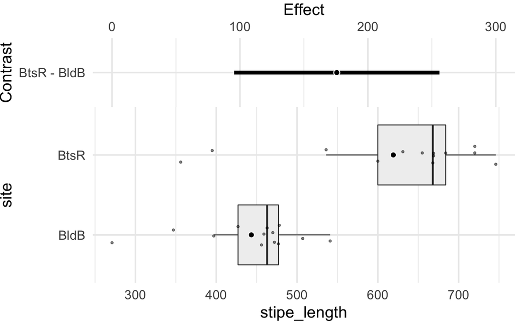

Harrell plot showing the distributions of stipe lengths (cm) of the kelp *Ecklonia maxima* at two different sites in the bottom panel. The top panel shows the confidence interval of the effect of the difference between these two sample sets based on a post-hoc Tukey test.

```r
# The easy creation of these figures has quite a few dependencies
library(lsmeans)
library(Hmisc)
library(broom)
library(car)
library(data.table)
library(cowplot)
source("../data/fit_model.R")
source("../data/make_formula_str.R")
source("../data/HarrellPlot.R")

# Load data
ecklonia <- read.csv("../data/ecklonia.csv")

# Create Harrell Plot
HarrellPlot(x = "site", y = "stipe_length", data = ecklonia, short = T)[1]
```

> **Task 2:** There are a lot of settings for `HarrellPlot()`, what do some of them do?

The above figure shows that the CI of the difference between stipe lengths (cm) at the two sites does not cross 0. This means that there is a significant difference between these two sample sets. But let’s run a statistical test anyway to check the results.

```r
# assumptions
ecklonia %>%
  group_by(site) %>%
  summarise(stipe_length_var = var(stipe_length),
            stipe_length_Norm = as.numeric(shapiro.test(stipe_length)[2]))
```

```
R> # A tibble: 2 × 3
R>   site           stipe_length_var stipe_length_Norm
R>   <chr>                     <dbl>             <dbl>
R> 1 Batsata Rock             14683.            0.0128
R> 2 Boulders Beach            4970.            0.0589
```

```r
# We fail both assumptions...

# non-parametric test
wilcox.test(stipe_length ~ site, data = ecklonia)
```

```
R>
R>  Wilcoxon rank sum test with continuity correction
R>
R> data:  stipe_length by site
R> W = 146, p-value = 0.001752
R> alternative hypothesis: true location shift is not equal to 0
```

The results of our Wilcox rank sum test, unsurprisingly, support the output of `HarrelPlot()`.

## Exercises

> **Exercise 1:** Create a combined tidy dataframe (observe tidy principles) with the estimates for the 95% CI for the teacher data, above, estimated using both the traditional and bootstrapping methods. Create a plot comprising two panels (one for the traditional estimates, one for the bootstrapped estimates) of the mean, median, scatter of raw data points, and the upper and lower 95% CI.

> **Exercise 2** Load a new dataset and create a Harrell plot from it based on values of your choosing. What does the Harrell plot show?